# GVPT 421 Final Project

Arthur Thomas

5/16/2018

## What affects suicide rates in the United States?

In the United States, there has been an increase in mental health concerns, whether it stems from the over-prescribing of opioids, mental instability of the youth who commit horrible acts, stress from school, depression from societal expectations, etc. it is a serious issue and it can often lead to suicide or self-harm. The US should begin to study this issue and strive to implement a set of policies that help people with their anxieties or other mental health issues and offer easier access to mental health care, such therapists or psychologists or possibly medication. Recently, there have been issues with mental health at UMD, sparking movements to get students to try to change the university’s policies/efforts. **Hypothesis:** I believe that variables such as Access to Mental Health Resources, Depression, Stress and Drug Usage by state all have effects to predicting the suicide rate of a state. In this report, I will show the effects these variables have on the DV.

## What is the narrative at UMD around mental health?

Recent University of Maryland Diamondback articles expressing the concern for UMD’s disregard for Mental health issues faced by students and how the university health center had a backup of over 30 days, which can lead to even worse mental health issues.

```r
mental <- readtext('mental.txt')
mental <- paste(mental$text, collapse=" ")
mental <- VectorSource(mental)
corpus <- Corpus(mental)
corpus <- tm_map(corpus, content_transformer(tolower))
corpus <- tm_map(corpus, removePunctuation)
corpus <- tm_map(corpus, stripWhitespace)
corpus <- tm_map(corpus, removeWords, stopwords("english"))
corpus <- tm_map(corpus, removeWords, c("student","|","-","“","","201516","201617","kirklandgordon",'schledwitz'))
#creating matrix
dtm <- DocumentTermMatrix(corpus)
dtm <- as.matrix(dtm)
frequency <- colSums(dtm)
frequency <- sort(frequency, decreasing=TRUE)
#5 Most common words:
head(frequency)
```

```
##   students     mental counseling university     center     health
##         60         42         39         36         32         31
```

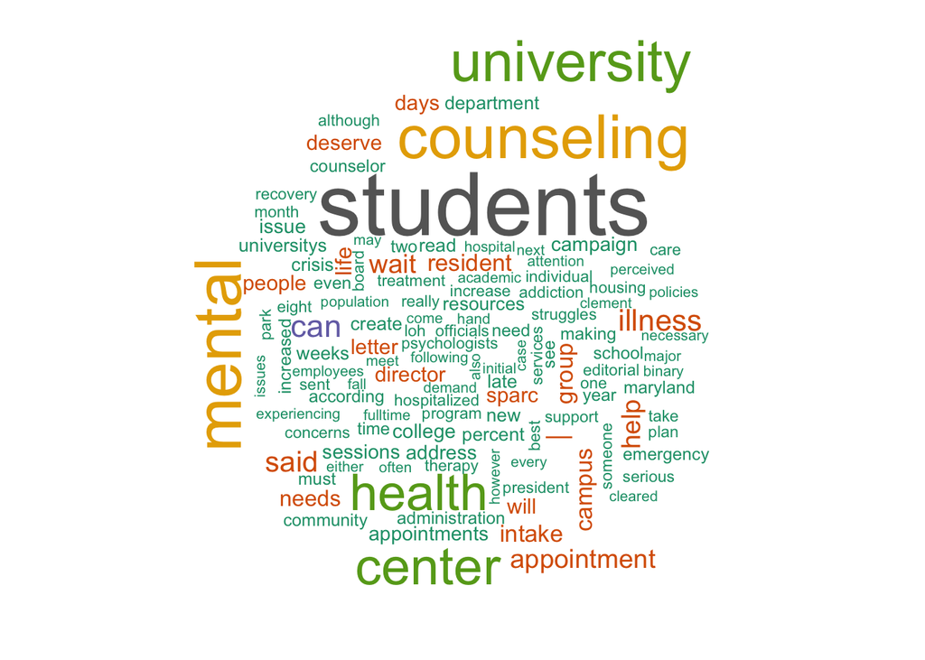

```r
words <- names(frequency)
#png("wordcloud_packages.png", width=15,height=15, units='in', res=300)
#wordcloud(words, scale=c(5,0.5), max.words=100, random.order=FALSE, rot.per=0.35, use.r.layout=FALSE, colors=brewer.pal(8, "Dark2"))
wordcloud(words[1:120], frequency[1:120],color=brewer.pal(8, "Dark2"))
```

# Variable Selection:

### Dependent Variable: Suicide Rate

The suicide rate variable comes from 2016 CDC report, which calculates the mortality rate calculated per the number of deaths per 100,000 total population. The higher the suicide rate, the more people (percentage wise) chose to end their lives. The average Suicide rate in the US is:

```r
mean(data$Suicide.Rate) #Suicide Rate
```

```
## [1] 15.792
```

*Source: https://www.cdc.gov/nchs/pressroom/sosmap/suicide-mortality/suicide.htm*

### Independent Variables

##### Depression

The depression reporting variable data comes from a 2010 CDC report regarding current depression among adults, with the higher percentages representing high rates of any overall depression in that state. The average Depression rate in the US is:

```r
mean(data$Depression.Rates) #Depression
```

```
## [1] 7.752
```

*Source: https://www.cdc.gov/mmwr/preview/mmwrhtml/mm5938a2.htm?s_cid=mm5938a2_w#tab1*

##### Drug Usage

The drug use variable data from the U.S. Census Bureau, with data included in the total measure consisting of “Percentage of Teenagers Who Used Illicit Drugs in the Past Month”, “Number of Opioid Pain Reliever Prescriptions per 100 People”, and numerous others to classify these states ranking their usage rates. The higher score indicates a higher prevalence of drug usage. The average Drug Usage rate in the US is:

```r
mean(data$Drug.Use)#Drug Usage
```

```
## [1] 41.8912
```

*Source: https://wallethub.com/edu/drug-use-by-state/35150/*

#### Stress

This variable is also from WalletHub, and is the total score between all stress results whether it comes from money, work, family or health issues. The higher number represents states with more stress/of the combined total of it. The average Stress rate in the US is:

```r
mean(data$Stress.Rate)#Stress Rate
```

```
## [1] 42.1186
```

*Source: https://wallethub.com/edu/most-stressful-states/32218/*

##### Access to Mental Health Resources

The access to mental health resources variable comes from 2014 data collected by the Mental Health America organization, and classifies the state by the overall ranking and the access to care ranking. A high overall (such as 1-10) ranking indicates a lower prevalence of mental illness and higher rates of access to care. A low overall ranking indicates a higher prevalence of mental illness and lower rates of access to care. The combined scores of all 15 measures make up the overall ranking. The overall ranking includes both adult and youth data. The average access to mental health in the US is:

```r
mean(data$Access.to.care)#Access to Menal Care
```

```
## [1] 25.5
```

*Source: http://www.mentalhealthamerica.net/issues/2017-state-mental-health-america-ranking-states*

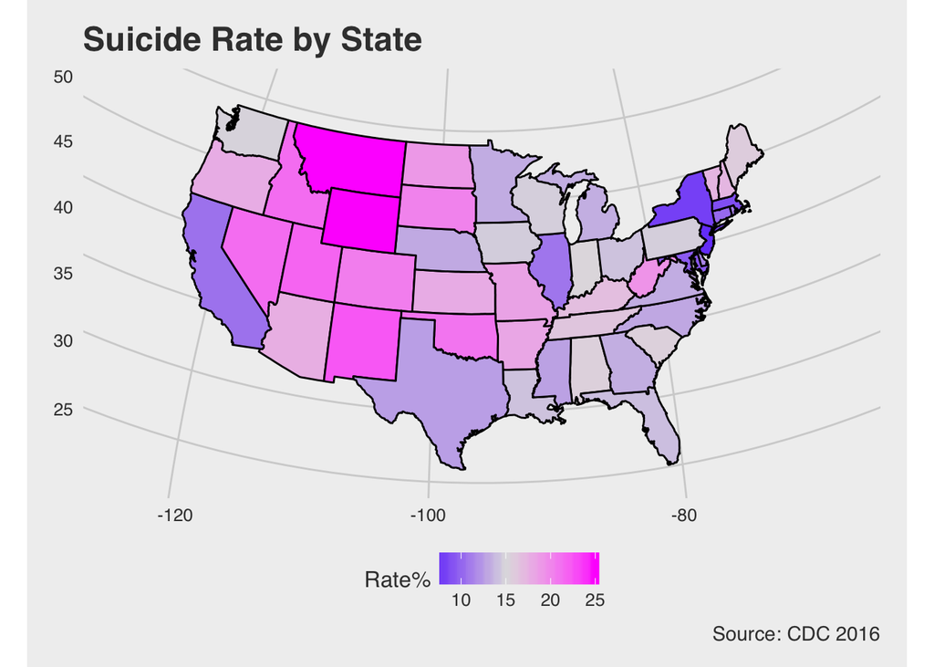

```r
#Mapping
#states_map<-map_data("states") #  run this in the command line, wont work outside of it for some reason.
data <-read.csv("finalprojectdata.csv")
data <- data.frame(data[,-1], row.names=data[,1])
states_map<-map_data("state")
#creating a seperate data variable for the depression rates map that is missing data.
dataDepresionMap <-data[which(data$Depression.Rates!="0"), ]
dataDepresionMap<-merge(states_map, dataDepresionMap, by.x="region", by.y="state")
dataDepresionMap<-arrange(dataDepresionMap, group, order)
#Merging State Data
dataMap<-merge(states_map, data, by.x="region", by.y="state")
dataMap<-arrange(dataMap, group, order)
#Suicide Rate Map
map<-ggplot(dataMap, aes(x=long, y=lat, group=group, fill=Suicide.Rate,  locationmode = dataMap$region)) +
  geom_polygon(color = "black") +
  scale_fill_gradient2(low="blue", mid="grey88", high="magenta", midpoint=median(data$Suicide.Rate))+
  expand_limits(x= states_map$long, y=states_map$lat) +
  ggtitle("Suicide Rate by State", subtitle = NULL) +
  labs(caption = "Source: CDC 2016") +
  labs(fill='Rate%')  + coord_map("bonne",  param=45)
map_map <- map+theme_fivethirtyeight()
#ggplotly(map)
#Access to Care Map
map1<-ggplot(dataMap, aes(x=long, y=lat, group=group, fill=Access.to.care)) +
  geom_polygon(color = "black") +
  scale_fill_gradient2(low="blue", mid="grey88", high="magenta", midpoint=median(data$Access.to.care))+
  expand_limits(x= states_map$long, y=states_map$lat) +
  coord_map("polyconic")+ggtitle("Access to Mental Health Care", subtitle = " Greater = less access")+labs(caption = "Source: Mental Health America 2014") + labs(fill=NULL)  + coord_map("bonne",  param=45)
#map1
#Depression Rate Map
map2<-ggplot(dataDepresionMap, aes(x=long, y=lat, group=group, fill=Depression.Rates)) +
  geom_polygon(color = "black") +scale_fill_gradient2(low="blue", mid="grey88", high="magenta", midpoint=median(dataDepresionMap$Depression.Rates))+
  expand_limits(x= states_map$long, y=states_map$lat) +
  coord_map("polyconic")+ggtitle("Any Depression Reporting", subtitle = NULL)+labs(caption = "Source: CDC 2010") +   labs(fill='Rate%')  + coord_map("bonne",  param=45)
#Drug Usage Map
map3<-ggplot(dataMap, aes(x=long, y=lat, group=group, fill=Drug.Use)) +
  geom_polygon(color = "black") +
  scale_fill_gradient2(low="blue", mid="grey88", high="magenta", midpoint=median(data$Drug.Use))+
  expand_limits(x= states_map$long, y=states_map$lat) +
  coord_map("polyconic")+ggtitle("Drug usage", subtitle = NULL)+labs(caption = "Source: U.S. Census Bureau")+ labs(fill='Usage%')  +
  coord_map("bonne",  param=45)
map4<-ggplot(dataMap, aes(x=long, y=lat, group=region, fill=Stress.Rate)) +
  geom_polygon(color = "black") +
  scale_fill_gradient2(low="blue", mid="grey88", high="red", midpoint=median(data$Stress.Rate))+
  expand_limits(x= states_map$long, y=states_map$lat) +
  coord_map("polyconic")+ggtitle("Stress Rank in the US", subtitle = NULL)+labs(caption = "Source: WalletHub")+ labs(fill='Stress Rank%')  +
  coord_map("bonne",  param=45)
#ggplotly(map_map)
map_map
```